# Mapping Surface Runoff Susceptibility in the Nisqually River Watershed, Washington

## Using a Fuzzy Logic Model Under Historical and Future Climate Conditions

**Author:** Nym Griggs  
**Course:** Earth Data Analytics Capstone - University of Colorado Boulder  
**Advisor:** Dr. Lilly Jones  
**Date:** July 2026

## Project Overview

This notebook maps surface runoff susceptibility across the Nisqually River Watershed using a fuzzy logic modeling framework. The analysis integrates topography, soils, land cover, and climate data to produce spatially continuous susceptibility maps under both historical (1976–2005) and projected future (2041–2070) climate conditions.

The resulting susceptibility maps are intended to serve as a watershed-scale screening tool for identifying areas that may be more susceptible to surface runoff and how that susceptibility may shift with climate change. This fuzzy logic model was selected as it is less resource and data intensive than many physically based hydrologic models, supporting targeted resource allocation and prioritization of high-risk areas. It is not intended to replace detailed hydrologic modeling, but rather offer a complementary tool to provide an accessible first-pass watershed-scale assessment when time, data, or computational resources are limited.

**Research Questions**

1. Where is surface runoff susceptibility highest in the Nisqually River Watershed under historical conditions?
2. Do projected mid-century increases in wet-season precipitation and storm intensity redistribute that risk, or simply intensify it where it already exists?

## Methods

Surface runoff susceptibility was modeled using a fuzzy logic framework that integrates topographic, impervious surface, hydrologic soil group, and climate variables to estimate the relative likelihood of surface runoff generation and concentration across the Nisqually River Watershed. The topographic inputs such as slope were derived from a Digital Elevation Model (DEM) and flow accumulation was calculated using the `pysheds` [Python library](https://github.com/pysheds/pysheds).

From the MACA climate dataset, mean wet-season (December–February) precipitation and Rx1day (maximum 1-day precipitation) were calculated. Rx1day was included as a proxy for storm intensity. Historical (1976–2005) and mid-century future (2041–2070) climate scenarios were analyzed using the Community Climate System Model Version 4 (CCSM4) under the Representative Concentration Pathway (RCP) 4.5 emissions scenario. CCSM4 was selected because its projections are representative of the average response across climate models for the region. The mid-century future period was chosen to balance capturing projected climate change impacts while remaining relevant for near- to medium-term planning and decision-making. Although this analysis uses CCSM4, the workflow can be readily adapted to other climate models available through the MACA dataset with minor modifications.

Each model input was transformed into a standardized fuzzy membership value ranging from 0 to 1, where higher values indicate a greater contribution to runoff susceptibility. Runoff generation and runoff concentration variables were modeled separately to better represent hydrological conditions, before being combined to produce the final surface runoff susceptibility map. The fuzzified layers were then combined using a fuzzy gamma overlay (γ = 0.85). The final workflow produced maps of historical runoff susceptibility, projected future runoff susceptibility, and projected changes in runoff susceptibility.

1. **Getting Started (Setup)**
   - Required Datasets
   - Import Libraries
   - Configure Project Directories
2. **Data Acquisition & Preparation**
   - Study Area
   - Digital Elevation Model (SRTM)
   - Land Cover (NLCD Impervious Surface)
   - Climate Data (MACA)
   - Hydrologic Soil Groups (gSSURGO)
3. **Data Processing**
   - Topography Analysis - Flow Accumulation & Slope
   - Climate Data Processing
   - Data Harmonization
4. **Fuzzy Logic Modeling**
   - Membership Functions
   - Fuzzification
   - Fuzzy Overlay
   - Runoff Susceptibility Model
5. **Results & Maps**
   - Historical Susceptibility
   - Future Susceptibility
   - Change Analysis
   - Interactive Visualization

## 1. Getting Started (Setup)

### 1.1 Required Datasets

Before running the notebook, download the required input datasets and place them in the appropriate project folders.

Run the notebook through **Section 1.3 (Configure Project Directories)** first - this automatically creates the folder structure below. Once created, place the downloaded datasets into their corresponding folders before continuing to run the rest of the notebook.

The SRTM Digital Elevation Model (DEM) and MACA climate datasets are accessed and downloaded programmatically within the notebook and do not require manual download.

**Note:** Although this workflow is configured for the Nisqually River Watershed (HUC8: 17110015), it can be adapted to other HUC8 watersheds with minor modifications.

##### 1. Watershed Boundary (USGS WBD)

- Source: https://www.usgs.gov/national-hydrography/watershed-boundary-dataset
- Map Downloader Link: https://apps.nationalmap.gov/downloader/#/
- Download the HUC8 watershed boundary that includes the Nisqually River watershed (HUC8: 17110015)
- Place files in: `data/watershed-boundary-dataset/`

##### 2. NLCD Impervious Surface

- Source: https://www.mrlc.gov/viewer/
- Product: NLCD Impervious Surface (30 m) for Study Area
- Place files in: `data/nlcd-impervious/`

##### 3. Soils (NRCS gSSURGO)

- Source: https://www.nrcs.usda.gov/resources/data-and-reports/gridded-soil-survey-geographic-gssurgo-database
- Download gSSURGO for Washington State (geodatabase)
- Place files in: `data/soils/`

All three datasets above (watershed boundary, NLCD impervious surface, and soils) are also included in the Zenodo data release as an alternative to downloading directly from the original sources.

### 1.2 Import Libraries

```python
# Work with files, folders, and file paths
import os
import pathlib
import zipfile
from pathlib import Path
from glob import glob

# Work with tabular data
import pandas as pd

# Perform numerical and scientific computations
import numpy as np

# Work with vector geospatial data
import geopandas as gpd

# Work with raster and multidimensional geospatial data
import rioxarray as rxr
import xarray as xr
import xrspatial

# Merge raster arrays
from rioxarray.merge import merge_arrays

# Control raster resampling during reprojection
from rasterio.enums import Resampling

# Calculate flow direction and flow accumulation from elevation data
from pysheds.grid import Grid

# Create static plots
import matplotlib.pyplot as plt

# Configure colormaps and color normalization
from matplotlib import colors
import matplotlib.cm as cm

# Create interactive plots from tabular and raster data
import hvplot.pandas
import hvplot.xarray

# Build interactive visualizations
import holoviews as hv

# Create interactive geographic visualizations
import geoviews as gv

# Coordinate reference systems
import cartopy.crs as ccrs

# Access NASA Earthdata products
import earthaccess

# Create fuzzy membership functions and perform fuzzy operations
import skfuzzy as fuzz
```

### 1.3 Configure Project Directories

```python
# Create base project directory
project_dir = os.path.abspath(os.path.join(os.getcwd(), "..", "data"))

# Define all directories in one dictionary
dirs = {
    "project": project_dir,
    "wbd": os.path.join(project_dir, "watershed-boundary-dataset"),
    "topography": os.path.join(project_dir, "topography"),
    "soils": os.path.join(project_dir, "soils"),
    "climate": os.path.join(project_dir, "climate"),
    "impervious": os.path.join(project_dir, "nlcd-impervious"),
    "inputs": os.path.join(project_dir, "final_inputs_5070"),
    "fuzzy": os.path.join(project_dir, "fuzzy_layers"),
    "final": os.path.join(project_dir, "final_outputs")
}

# Create all directories
for path in dirs.values():
    os.makedirs(path, exist_ok=True)

# Assign individual dir variables
wbd_dir = dirs["wbd"]
topography_dir = dirs["topography"]
soils_dir = dirs["soils"]
climate_dir = dirs["climate"]
impervious_dir = dirs["impervious"]
fuzzy_dir = dirs["fuzzy"]
final_dir = dirs["final"]

# Check one of them
print(wbd_dir)
print(os.path.exists(wbd_dir))
```

## 2. Data Acquisition & Preparation

### 2.1 Study Area

```python
# Path to the downloaded zip file
zip_path = os.path.join(wbd_dir, "WBD_17_HU2_GPKG.zip")

# Extracted directory path
extract_dir = os.path.join(wbd_dir, "extracted")
os.makedirs(extract_dir, exist_ok=True)

# Unzip the file
with zipfile.ZipFile(zip_path, 'r') as zip_ref:
    zip_ref.extractall(extract_dir)

# Path to GeoPackage (after unzip)
wbd_gpkg_path = os.path.join(extract_dir, "WBD_17_HU2_GPKG.gpkg")

# Read HUC8 layer
wbd_gdf = gpd.read_file(wbd_gpkg_path, layer="WBDHU8")

# Check the first few rows
print(wbd_gdf.head())
```

```python
# Check the columns
print(wbd_gdf.columns)
```

```python
# Check the geometry type
wbd_gdf.head()
```

```python
# Check for the Nisqually watershed
wbd_gdf[wbd_gdf["name"].str.contains("Nisqually", case=False)]
```

```python
# Subset to just the Nisqually watershed
nisqually_gdf = wbd_gdf[wbd_gdf["huc8"] == "17110015"]
```

```python
# Check the name of the watershed
print(nisqually_gdf["name"])
```

```python
# Plot to see that it worked
nisqually_gdf.plot()
```

```python
# Plot the results with web tile images
nisqually_gdf_plot = nisqually_gdf.hvplot(
    geo=True, tiles='EsriImagery',
    fill_color=None, line_color='white',
    title='Nisqually Watershed (HUC8)',
    frame_width=500,
    xlabel="Longitude",
    ylabel="Latitude")

# Display the plot with esri imagery
nisqually_gdf_plot
```

### 2.2 Digital Elevation Model (SRTM - 30 m resolution)

```python
# Set up Earth Access
earthaccess.login()
```

```python
# Search for SRTM data
datasets = earthaccess.search_datasets(keyword = "SRTM DEM")
for dataset in datasets:
    print(dataset['umm']['ShortName'], dataset['umm']['EntryTitle'])
```

```python
# File pattern for data
nisqually_gdf_srtm_pattern = os.path.join(topography_dir, '*.hgt.zip')

# Study area for topo data
nisqually_gdf_elev_bounds = tuple(nisqually_gdf.total_bounds)

# Add buffer
buffer = 0.025
nisqually_xmin, nisqually_ymin, nisqually_xmax, nisqually_ymax = nisqually_gdf_elev_bounds
nisqually_elev_bounds_buffer = (nisqually_xmin - buffer,
                                 nisqually_ymin - buffer,
                                 nisqually_xmax + buffer,
                                 nisqually_ymax + buffer)

# Look at the results
srtm_files = glob(nisqually_gdf_srtm_pattern)

if not srtm_files:

    # Search for data
    nisqually_gdf_srtm_search = earthaccess.search_data(
        short_name = 'SRTMGL3',
        bounding_box = nisqually_elev_bounds_buffer
    )

    # Download data
    nisqually_gdf_srtm_results = earthaccess.download(
        nisqually_gdf_srtm_search,
        topography_dir
    )

# Add text if files already downloaded
else:
    print("SRTM files already downloaded")
    nisqually_gdf_srtm_results = srtm_files
```

```python
# Check it out
nisqually_gdf_srtm_results
```

```python
# Create list to plot DEM
nisqually_gdf_srtm_da_list = []
for srtm_path in glob(nisqually_gdf_srtm_pattern):
    tile_da = rxr.open_rasterio(srtm_path, mask_and_scale = True).squeeze()
    srtm_cropped_da = tile_da.rio.clip_box(*nisqually_elev_bounds_buffer)
    nisqually_gdf_srtm_da_list.append(srtm_cropped_da)

# Merge
nisqually_srtm_da = merge_arrays(nisqually_gdf_srtm_da_list)

nisqually_srtm_da.plot(cmap='terrain', cbar_kwargs={'label': 'Elevation (meters)'})

nisqually_gdf.boundary.plot(ax = plt.gca(), color='black')

# Add title
plt.title("topo_elevation_nisqually")

# Check it out
plt.show()
```

```python
# Save the merged raster to a new file
# Create a copy of the data array to modify for saving
nisqually_save_da = nisqually_srtm_da.copy()

# Remove any existing _FillValue attribute and encoding to avoid issues when writing the raster
nisqually_save_da.attrs.pop("_FillValue", None)

# Remove any existing _FillValue from encoding and set the nodata value to -9999
nisqually_save_da.encoding.pop("_FillValue", None)
nisqually_save_da = nisqually_save_da.rio.write_nodata(-9999)

# Create the path for the new raster file
dem_path = os.path.join(topography_dir, "nisqually_dem.tif")

# Save the raster to a new file
nisqually_save_da.rio.to_raster(dem_path)

# Check that the file was saved correctly
print(dem_path)
print(os.path.exists(dem_path))
```

```python
# Check the min and max values
print(nisqually_srtm_da.min().values)
print(nisqually_srtm_da.max().values)
```

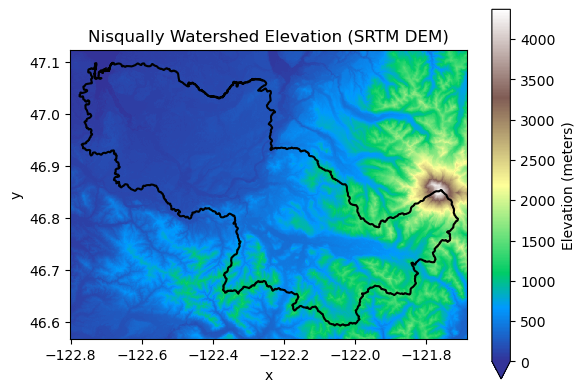

```python
# Plot with limits for better visualization
nisqually_srtm_da.plot(
    cmap="terrain",
    vmin=0,
    vmax=float(nisqually_srtm_da.max()),
    cbar_kwargs={"label": "Elevation (meters)"}
)

# Add watershed boundary
nisqually_gdf.boundary.plot(ax=plt.gca(), color="black")
plt.title("Nisqually Watershed Elevation (SRTM DEM)")
plt.show()
```

```python
# Reproject the SRTM DEM to 5070 to calculate slope later
nisqually_rpj = nisqually_srtm_da.rio.reproject("EPSG:5070")

# Create a copy of the data array to modify for saving
save_da = nisqually_rpj.copy()

# Remove any existing _FillValue attribute and encoding to avoid issues when writing the raster
save_da.attrs.pop("_FillValue", None)

# Remove any existing _FillValue from encoding and set the nodata value to -9999
save_da.encoding.pop("_FillValue", None)
save_da = save_da.astype("float32").fillna(-9999)

# Write the nodata value to the raster metadata
save_da = save_da.rio.write_nodata(-9999)

# Create the path for the new raster file
dem_5070_path = os.path.join(topography_dir, "nisqually_dem_5070.tif")

# Save the raster as float32 with nodata value of -9999
save_da.rio.to_raster(dem_5070_path, dtype="float32")
```

### 2.3 Land Cover (NLCD Impervious Surface)

```python
# Path to zip file
zip_path = os.path.join(impervious_dir, "NLCD_84d4ec6e-782d-4ca1-985c-369c3d869faf.zip")

# Unzip to the same directory
with zipfile.ZipFile(zip_path, "r") as z:
    z.extractall(impervious_dir)

# Check the extracted files
print("Unzipped successfully")
```

```python
# List the files in the impervious directory to see the extracted contents
for file in os.listdir(impervious_dir):
    print(file)
```

```python
# Find the tif
tif_files = [
    f for f in os.listdir(impervious_dir)
    if f.lower().endswith((".tif", ".tiff"))
]

# Check the tif files found
impervious_path = os.path.join(impervious_dir, tif_files[0])

# Open it
impervious_da = rxr.open_rasterio(impervious_path, masked=True).squeeze()

# Check the dataarray
print(impervious_da)
```

```python
# Check CRS, bounds, and resolution
print(impervious_da.rio.crs)
print(impervious_da.rio.bounds())
print(impervious_da.rio.resolution())
```

```python
# Reproject impervious to crs 5070
impervious_5070 = impervious_da.rio.reproject("EPSG:5070")
```

```python
nisqually_gdf_5070 = nisqually_gdf.to_crs("EPSG:5070")

impervious_clip = impervious_5070.rio.clip(
    nisqually_gdf_5070.geometry,
    nisqually_gdf_5070.crs,
    drop=True
)
```

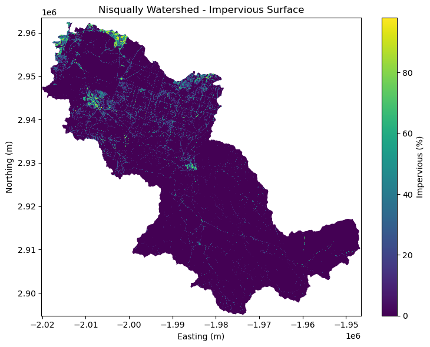

```python
fig, ax = plt.subplots(figsize=(8, 6))

impervious_clip.plot(
    ax=ax,
    cmap="viridis",
    cbar_kwargs={"label": "Impervious (%)"}
)

nisqually_gdf_5070.boundary.plot(
    ax=ax,
    edgecolor="white",
    linewidth=1.5
)

ax.set_title("Nisqually Watershed - Impervious Surface")
ax.set_xlabel("Easting (m)")
ax.set_ylabel("Northing (m)")
plt.tight_layout()
plt.show()
```

```python
# Create function to clean and save, fill no data
def clean_and_save(da, path):
    """Function to clean the data array and save it to a raster file.

    Args:
    da (xarray.DataArray): The data array to clean and save
    path (str): The file path to save the raster to

    Returns:
    None
    """
    save_da = da.copy()
    save_da.attrs.pop("_FillValue", None)
    save_da.encoding.pop("_FillValue", None)
    save_da = save_da.astype("float32")
    save_da = save_da.fillna(-9999)
    save_da = save_da.rio.write_nodata(-9999)
    save_da.rio.to_raster(path, dtype="float32")
    print(f"Saved: {path}")
```

```python
# Create path to nisqually impervious
impervious_5070_path = os.path.join(
    impervious_dir,
    "nisqually_impervious_5070.tif"
)

# Apply the function
clean_and_save(impervious_clip, impervious_5070_path)
```

### 2.4 Climate Data (MACA)

```python
# Create function to convert longitude values
def convert_longitude(longitude):

    """
    Function to convert longitude

    Args:
    longitude:

    Returns:Function to convert longitude
    """

    return (longitude - 360) if longitude > 180 else longitude
```

```python
# Create directory for file
climate_pattern = os.path.join(climate_dir, '*.nc')
climate_pattern
```

```python
# Define some parameters
site_name = "Nisqually"
site_gdf = nisqually_gdf
date_range = "2041_2045"
model = "CCSM4"
rcp_value = "rcp45"
climate_var = "pr"
```

```python
# Create a maca path
climate_path = os.path.join(
    climate_dir,
    f"maca_{model}_{site_name}_{date_range}_CONUS_daily.nc"
)
```

```python
# Construct the URL where the climate data lives
climate_url = (
    "http://thredds.northwestknowledge.net:8080/thredds/dodsC"
    "/MACAV2"
    f"/{model}"
    "/macav2metdata"
    f"_{climate_var}"
    f"_{model}_r6i1p1"
    f"_{rcp_value}"
    f"_{date_range}_CONUS"
    "_daily.nc"
)
```

```python
# Check out the url
climate_url
```

```python
# Open the dataset using xarray
ds = xr.open_dataset(climate_url)
print(ds.data_vars)
```

```python
# Check if the variable is "pr" or "precipitation" and assign to climate_da
climate_da = ds["pr"] if "pr" in ds.data_vars else ds["precipitation"]
print(climate_da)
```

```python
# Check remote point values to make sure it looks right
pt_raw = climate_da.sel(lat=46.85, lon=237.8, method="nearest")
print("Remote raw point min/max:", float(pt_raw.min()), float(pt_raw.max()))
```

```python
# Convert longitude values to the range [-180, 180]
climate_da = climate_da.assign_coords(
    lon=(((climate_da.lon + 180) % 360) - 180).data
).sortby("lon")
```

```python
# Check the converted point values to make sure it looks right
pt_conv = climate_da.sel(lat=46.85, lon=-122.2, method="nearest")
print("Remote converted point min/max:", float(pt_conv.min()), float(pt_conv.max()))
```

```python
# Match the CRS of the climate data to the watershed boundary
nisqually_4326 = nisqually_gdf.to_crs("EPSG:4326")

# Create a bounding box for the watershed
minx, miny, maxx, maxy = nisqually_4326.total_bounds
print(minx, miny, maxx, maxy)
```

```python
# Crop the climate data to the bounding box of the watershed
climate_da_cropped = climate_da.sel(
    lon=slice(minx, maxx),
    lat=slice(miny, maxy)
)
```

```python
# Check the cropped point values to make sure it looks right
pt_crop = climate_da_cropped.sel(lat=46.85, lon=-122.2, method="nearest")
print("Remote cropped point min/max:", float(pt_crop.min()), float(pt_crop.max()))

# Check the cropped slice values to make sure it looks right
test_crop = climate_da_cropped.isel(time=0)
print("Remote cropped slice min/max:", float(test_crop.min()), float(test_crop.max()))
print(climate_da_cropped.shape)
```

```python
# Load the cropped subset into memory
climate_da_cropped = climate_da_cropped.load()
print("Cropped subset loaded into memory")
```

```python
# Create path for cropped file
cropped_path = os.path.join(
    climate_dir,
    "maca_CCSM4_Nisqually_2041_2045_cropped.nc"
)

if not os.path.exists(cropped_path):
    climate_da_cropped.to_netcdf(cropped_path)
    print("Saved cropped file:", cropped_path)
else:
    print("File already exists, not overwriting:", cropped_path)
```

```python
# Check the cropped file by opening it again
ds_check = xr.open_dataset(cropped_path)
print(ds_check.data_vars)

# Check if the variable is "pr" or "precipitation" and assign to check_da
check_da = ds_check["precipitation"] if "precipitation" in ds_check.data_vars else ds_check["pr"]

# Check the cropped point values to make sure it looks right
pt_check = check_da.sel(lat=46.85, lon=-122.2, method="nearest")
print("Local cropped point min/max:", float(pt_check.min()), float(pt_check.max()))

# Check the cropped slice values to make sure it looks right
test_check = check_da.isel(time=0)
print("Local cropped slice min/max:", float(test_check.min()), float(test_check.max()))
```

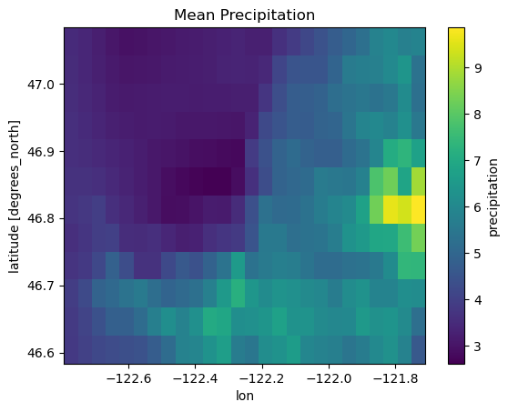

```python
# Plot the mean precipitation to check it out
climate_mean = check_da.mean(dim="time")
climate_mean.plot()

# Add title
plt.title("Mean Precipitation")
plt.show()
```

```python
# Check the min and max values of the mean precipitation
print(float(climate_mean.min()), float(climate_mean.max()))
```

```python
# Check the shape of the cropped data array
climate_da_cropped.shape
```

#### Function for downloading all maca data cropped precip

```python
# Create function to get all climate data
# *Created with help of ChatGPT, refined by author*
def get_maca_cropped_precip(
    model,
    scenario,
    date_range,
    watershed_gdf,
    climate_dir,
    site_name="Nisqually",
):
    """
    Function to open a remote MACA daily precipitation dataset for one time chunk,
    convert longitude from 0-360 to -180-180, crop to the watershed
    bounding box, load the cropped daily subset into memory, and save
    it locally as a NetCDF file.

    Args:
    model (str): MACA climate model name, e.g. "CCSM4".
    scenario (str): Scenario name, e.g. "historical", "rcp45", or "rcp85".
    date_range (str): Time chunk string, e.g. "1975_1979" or "2041_2045".
    watershed_gdf (geopandas.GeoDataFrame): Watershed boundary used for cropping.
    climate_dir (str): Directory where the cropped NetCDF file will be saved.
    site_name (str): Name of the study site for use in the output filename. Defaults to "Nisqually".

    Returns
    str: Path to the saved cropped NetCDF file.
    """

    # MACA ensemble convention
    ensemble = "r6i1p1" if model == "CCSM4" else "r1i1p1"

    # Build filename differently for historical vs future scenarios
    if scenario == "historical":
        remote_filename = (
            f"macav2metdata_pr_{model}_{ensemble}_historical_{date_range}_CONUS_daily.nc"
        )
    else:
        remote_filename = (
            f"macav2metdata_pr_{model}_{ensemble}_{scenario}_{date_range}_CONUS_daily.nc"
        )

    # Build remote URL
    climate_url = (
        "http://thredds.northwestknowledge.net:8080/thredds/dodsC"
        f"/MACAV2/{model}/{remote_filename}"
    )

    # Build local output path
    out_path = os.path.join(
        climate_dir,
        f"maca_{model}_{scenario}_{site_name}_{date_range}_cropped.nc"
    )

    # Skip if already exists
    if os.path.exists(out_path):
        print(f"Already exists: {out_path}")
        return out_path

    # Print message about opening remote dataset
    print(f"Opening remote dataset for {scenario} {date_range}...")

    # Open remote dataset
    ds = xr.open_dataset(climate_url)

    # Grab precipitation variable
    climate_da = ds["pr"] if "pr" in ds.data_vars else ds["precipitation"]

    # Convert longitude from 0-360 to -180-180 and sort
    climate_da = climate_da.assign_coords(
        lon=(((climate_da.lon + 180) % 360) - 180).data
    ).sortby("lon")

    # Watershed bounds in EPSG:4326 to match MACA coordinates
    watershed_4326 = watershed_gdf.to_crs("EPSG:4326")
    bounds = watershed_4326.total_bounds

    # Add buffer
    buffer = 0.05
    xmin, ymin, xmax, ymax = bounds
    bounds_buffer = (xmin - buffer, ymin - buffer, xmax + buffer, ymax + buffer)

    # Crop to buffered bounding box
    climate_da_cropped = climate_da.sel(
        lon=slice(bounds_buffer[0], bounds_buffer[2]),
        lat=slice(bounds_buffer[1], bounds_buffer[3])
    )

    # Load cropped subset into memory before saving
    climate_da_cropped = climate_da_cropped.load()

    # Quick sanity check on first day
    test = climate_da_cropped.isel(time=0)
    print("First-day cropped min/max:", float(test.min()), float(test.max()))

    # Save cropped daily data
    climate_da_cropped.to_netcdf(out_path)

    # Close remote dataset
    ds.close()

    print(f"Saved: {out_path}")
    return out_path
```

```python
# Make sure function works by running it for one time chunk
test_path = get_maca_cropped_precip(
    model="CCSM4",
    scenario="rcp45",
    date_range="2046_2050",
    watershed_gdf=nisqually_gdf,
    climate_dir=climate_dir,
    site_name="Nisqually"
)

# Check the output path
print(test_path)
```

```python
# Define historical date range for looping
historical_ranges = [
    "1975_1979",
    "1980_1984",
    "1985_1989",
    "1990_1994",
    "1995_1999",
    "2000_2004",
    "2005_2005",
]

# Define future date range for looping
future_ranges = [
    "2041_2045",
    "2046_2050",
    "2051_2055",
    "2056_2060",
    "2061_2065",
    "2066_2070",
]
```

```python
# Create loop for all historical and future time chunks
saved_files = []

# Loop through historical ranges
for tr in historical_ranges:
    saved_files.append(
        get_maca_cropped_precip(
            model="CCSM4",
            scenario="historical",
            date_range=tr,
            watershed_gdf=nisqually_gdf,
            climate_dir=climate_dir,
            site_name="Nisqually",
        )
    )

# Loop through future ranges
for tr in future_ranges:
    saved_files.append(
        get_maca_cropped_precip(
            model="CCSM4",
            scenario="rcp45",
            date_range=tr,
            watershed_gdf=nisqually_gdf,
            climate_dir=climate_dir,
            site_name="Nisqually",
        )
    )

# Check the list of saved files
saved_files
```